Building applied AI for real decisions

AI · DATA SCIENCE · BUSINESS INTELLIGENCE

# Turning complex data into *systems people can trust.*

I’m Vijay Bommireddy, a Business Intelligence Analyst and AI practitioner connecting research-grade machine learning with production analytics, healthcare operations, and reliable data platforms.

View selected work ↓[LinkedIn ↗](https://www.linkedin.com/in/vijaykumareddybommireddy/)

**3.97**MS GPA

**60+**Dashboards launched

**50%**Edge latency reduction

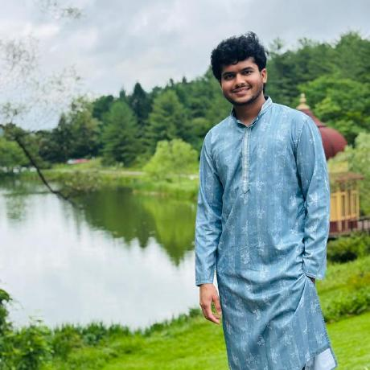

Current role**Business Intelligence Analyst**LifeLine of Ohio

Focus**AI × Analytics**Research to production

AGENTIC AI ✦ HEALTHCARE ANALYTICS ✦ MACHINE LEARNING ✦ MLOPS ✦ DATA PLATFORMS ✦ BUSINESS INTELLIGENCE ✦ AGENTIC AI ✦ HEALTHCARE ANALYTICS

01

Selected projects

## Built for relevance. *Designed for impact.*

Six projects selected for today’s strongest AI and data needs: trustworthy agents, grounded LLMs, MLOps, anomaly detection, streaming systems, and operational ML.

01 / 06Trustworthy agent evaluation

[figure not shown]

Trajectory-level trustworthiness

### VALID-Agent

A research framework that moves beyond pass/fail benchmarks to inspect how an AI agent succeeds. Its Success Validity Score evaluates plan consistency, redundant and unsafe actions, tool necessity, and recovery quality.

PythonAgentic AIEvaluation

[Explore repository ↗](https://github.com/Vijay-glitch495/VALID-Agent)

02 / 06Grounded healthcare AI

D1D2**RAG**Grounded answer

Evidence-grounded responses

### Medical RAG Chatbot

A retrieval-augmented medical assistant developed with an end-to-end LLMOps path, including containerization, automated testing, vulnerability scanning, CI/CD, and cloud deployment workflows.

RAGLLMOpsDocker

[Explore repository ↗](https://github.com/Vijay-glitch495/RAG_MEDICAL_CHATBOT)

03 / 06Predictive maintenance

[figure not shown]

Sensor-to-decision workflow

### Equipment Health Monitoring

A CRISP-DM machine-learning workflow that classifies industrial equipment failure types from sensor data, handles class imbalance, explains model behavior, and serves predictions through Streamlit.

Scikit-learnSMOTENCStreamlit

[Explore repository ↗](https://github.com/Vijay-glitch495/Equipment-Health-Monitoring-System)

04 / 06Operational intelligence

ANOMALY

Real-time anomaly signals

### Time-Series Anomaly Detection

A forecasting and anomaly-detection study using statistical and predictive models to identify abnormal patterns in noisy temporal data while tracking precision, recall, and forecasting error.

ARIMAProphetPython

[Explore repository ↗](https://github.com/Vijay-glitch495/Time-series-anomaly-detection)

05 / 06Production data engineering

APIKafkaSparkDB

End-to-end event processing

### Real-Time Streaming Pipeline

A containerized event-data architecture spanning ingestion, orchestration, streaming, distributed processing, and storage with Airflow, Kafka, Spark, PostgreSQL, and Cassandra.

KafkaSparkAirflow

[Explore repository ↗](https://github.com/Vijay-glitch495/Real-Time-Streaming-Pipeline)

06 / 06Cloud-native AI systems

A1A2A3**ORCHESTRATOR**

Deployable agent workflow

### Multi-Agent Chatbot

A conversational AI build with an operations-first deployment path: containerized services, CI/CD, cloud infrastructure, security scanning, and monitoring for reliable iteration.

AgentsAWSCI/CD

[Explore repository ↗](https://github.com/Vijay-glitch495/MULTI_AI_AGENT_CHATBOT)

[Explore the full GitHub portfolio ↗](https://github.com/Vijay-glitch495?tab=repositories)

02

Experience

## From insight *to operation.*

A career shaped by one recurring goal: shorten the distance between a useful model and a decision that matters.

01

FEB 2025 — PRESENT

Columbus, Ohio

LifeLine of Ohio

### Business Intelligence Analyst

**Building decision systems at the intersection of analytics, AI, and organ-donation operations.**

- Launched 60+ Power BI and Tableau dashboards, reducing turnaround time by 40% and scaling delivery capacity by 35% through structured requirements and n8n automation.
- Applied SiEBERT to organizational survey analysis, improving resource-allocation accuracy by 22% and helping leadership resolve engagement gaps faster.
- Built a DARTS, MLflow, and Airflow forecasting pipeline with automated drift detection and retraining, removing 60% of manual intervention and saving 8+ hours weekly.
- Developed a Temporal Fusion Transformer for DCD time-to-death prediction, reducing false viability assessments by 30%.
- Engineered a quantized multimodal LLM chatbot with Agentic RAG and REST-based MCP integrations, running on CPU while lowering infrastructure cost and analyst query time.

02

JAN 2024 — MAY 2024

Fishers, Indiana

Clear Object

### Data Scientist Intern

**Turning manufacturing vision models into lower-latency, edge-ready systems.**

- Fine-tuned YOLOv8 on a custom manufacturing image dataset with data engineering and cloud architecture teams.
- Integrated a Vertex AI CI/CD pipeline for data collection and training, cutting deployment time from five days to three.
- Converted a segmentation model to ONNX and deployed it with Docker on edge IoT devices, reducing inference latency from 200 ms to 100 ms.
- Implemented anomaly alerts that shortened maintenance response and helped avoid emergency downtime costs.

03

DEC 2021 — DEC 2022

India

IIEDC — NIT Srinagar

### Data Scientist

**Developing data APIs, statistical studies, and ensemble models for high-volume research and business data.**

- Designed CMR exchange and processing APIs for real-time datasets exceeding 10 million rows and 200 columns, enabling faster analytics and Tableau reporting.
- Automated financial-data reshaping with VBA, saving more than five hours of manual work each week.
- Applied hypothesis testing and performance evaluation to strengthen model reliability and validity.
- Developed ensemble models for research publications, improving predictive accuracy by 15% with optimized AUC-ROC evaluation.

Research direction

## Useful AI is more than a strong final answer.

My current research interest is trustworthy evaluation for agentic systems. VALID-Agent studies the process behind an outcome—whether the agent’s plan, tool use, safety, efficiency, and recovery behavior deserve confidence.

[Google Scholar ↗](https://scholar.google.com/citations?user=rnRZpr8AAAAJ&hl=en)[Research code ↗](https://github.com/Vijay-glitch495/VALID-Agent)

SUCCESS VALIDITY LENSEvaluate process, not only outcome

**SVS**TRUST SCORE

PCS

Plan consistency

RAR

Action efficiency

UAR

Safety

RBQ

Recovery quality

03 / EDUCATION

Indiana University Indianapolis

## Master of Science in Data Science

**3.97 / 4.0 GPA**Jan 2023 — Dec 2024

Informatics · Statistics · Data Analytics · Machine Learning · Deep Learning · Cloud Computing

04 / CAPABILITIES

01

### Applied AI

Agentic RAG, multimodal LLMs, MCP integrations, NLP, SiEBERT

02

### Machine learning

Forecasting, classification, clustering, deep learning, model evaluation

03

### MLOps & cloud

MLflow, Airflow, Vertex AI, AWS, GCP, Docker, CI/CD, drift monitoring

04

### Data platforms

Python, SQL, Spark, Snowflake, BigQuery, MySQL, SQL Server

05

### Analytics

Power BI, Tableau, Looker, Excel, statistics, experimentation

Collaboration & opportunities

## Let’s turn a difficult problem into a *working system.*

For applied AI, data science, analytics, research, or engineering conversations, contact me directly or explore the work behind this portfolio.

vijaybommireddy1@gmail.com ↗+1 (614) 623-9233

[LinkedIn ↗](https://www.linkedin.com/in/vijaykumareddybommireddy/)[GitHub ↗](https://github.com/Vijay-glitch495)[Scholar ↗](https://scholar.google.com/citations?user=rnRZpr8AAAAJ&hl=en)[Tableau ↗](https://public.tableau.com/app/profile/vijay.bommireddy)[Résumé ↗](https://vijay-ai-portfolio.cs23b2011.chatgpt.site/Vijay_Bommireddy_Resume.pdf)